# Exploring London's EU Referendum Vote through Ward based Census Data and Election Results

## Part 2 - Geodemographic Classification and Cluster Analysis with R

1. Picturing the Vote
2. Cluster Analysis
3. Comparing Geodemographic Classification and EU Referendum Vote
4. Regional Context
5. Political Context
6. Swing Measurment
7. Summary Visualisations
8. MRP
- In the previous section our Machine Learning Analysis Workflow produced a set of Independent Variables that might be strongly associated with the Leave Vote. In this section we focus on the spatial context of this narrative through Cluster Analysis and visual comparison of the Regional & National Referendum result distribution.
- We use the Jupyter IRKernel to incorporate R Functionality into the Jupyter Notebook format

### Setup

```r
library(maptools)
library(RColorBrewer)
library(classInt)
library(OpenStreetMap)
library(sp)
library(rgeos)
library(tmap)
library(tmaptools)
library(sf)
library(rgdal)
library(geojsonio)
library(grid)
```

```r
library(tidyverse)
```

## 1 - Visual and Spatial Context

- Establish Location and Spatial Distribution of the Leave and Remain Vote

#### Load Ward ShapeFile

```r
#sink("output.txt")
WardMapSF1 <- read_shape(paste("C:\\Users\\Admin\\ml16\\",
        "Wards_December_2016_Generalised_Clipped_Boundaries_in_Great_Britain\\",
            "Wards_December_2016_Generalised_Clipped_Boundaries_in_Great_Britain.shp", sep=""))
```

#### Load Census and Election Results Data Model

```r
UKData2 <-read_csv("C:\\Users\\Admin\\ml16\\uk-ward-results-edit4.csv")
LondonData4 <- data.frame(UKData2)
```

#### SF to SP Conversion

```r
library(methods)
#check the class of BoroughMapSF
class(WardMapSF1)
newSP <- as(WardMapSF1, "Spatial")
class(newSP)
```

1. 'sf'

2. 'data.frame'

'SpatialPolygonsDataFrame'

```r
head(newSP)
```

```
class       : SpatialPolygonsDataFrame
features    : 6
extent      : 543417.3, 551943.8, 183488.5, 191137.3  (xmin, xmax, ymin, ymax)
crs         : +proj=tmerc +lat_0=49 +lon_0=-2 +k=0.9996012717 +x_0=400000 +y_0=-100000 +ellps=airy +towgs84=446.448,-125.157,542.06,0.1502,0.247,0.8421,-20.4894 +units=m +no_defs
variables   : 12
names       : objectid,    wd16cd,   wd16nm, wd16nmw,   lad16cd,              lad16nm,  bng_e,  bng_n,     long,         lat,       st_areasha,       st_lengths
min values  :        1, E05000026,    Abbey,      NA, E09000002, Barking and Dagenham, 544434, 183978, 0.081291, 51.53580856, 1247619.42118614, 6246.79701737779
max values  :        6, E05000031, Eastbury,      NA, E09000002, Barking and Dagenham, 550774, 189340, 0.173453,  51.5834198, 3449511.08349383, 9496.48460786305
```

#### Filter on Londonwide Wards

```r
LondonWMap <- newSP[grep("^E09",newSP@data$lad16cd),]
```

#### SP to SF Conversion

```r
newSF <- st_as_sf(LondonWMap)
```

```r
head(newSF)
```

|  | objectid | wd16cd | wd16nm | wd16nmw | lad16cd | lad16nm | bng_e | bng_n | long | lat | st_areasha | st_lengths | geometry |
| --- | --- | --- | --- | --- | --- | --- | --- | --- | --- | --- | --- | --- | --- |
| 0 | 1 | E05000026 | Abbey | NA | E09000002 | Barking and Dagenham | 544434 | 184378 | 0.081291 | 51.53982 | 1247619 | 7858.341 | MULTIPOLYGON (((543619.8 18... |
| 1 | 2 | E05000027 | Alibon | NA | E09000002 | Barking and Dagenham | 549247 | 185196 | 0.150987 | 51.54592 | 1355411 | 6246.797 | MULTIPOLYGON (((548100.4 18... |
| 2 | 3 | E05000028 | Becontree | NA | E09000002 | Barking and Dagenham | 546863 | 185869 | 0.116912 | 51.55260 | 1289741 | 6280.316 | MULTIPOLYGON (((546126.3 18... |
| 3 | 4 | E05000029 | Chadwell Heath | NA | E09000002 | Barking and Dagenham | 548266 | 189340 | 0.138596 | 51.58342 | 3382297 | 9496.485 | MULTIPOLYGON (((547715.2 18... |
| 4 | 5 | E05000030 | Eastbrook | NA | E09000002 | Barking and Dagenham | 550774 | 186272 | 0.173453 | 51.55519 | 3449511 | 8857.773 | MULTIPOLYGON (((549991.5 18... |
| 5 | 6 | E05000031 | Eastbury | NA | E09000002 | Barking and Dagenham | 546074 | 183978 | 0.104756 | 51.53581 | 1436533 | 6740.558 | MULTIPOLYGON (((544735.2 18... |

```r
head(LondonData4)
```

| WardCode | WardName | CountingArea | Remain | Leave | Postals | Remain. | Leave. | Remain_Yes | Leave_Yes | Remain_Yes_Only | Leave_Yes_Only | Remain_Leave_Missing | RemainR. | LeaveR. |
| --- | --- | --- | --- | --- | --- | --- | --- | --- | --- | --- | --- | --- | --- | --- |
| S13002486 | Airyhall/Broomhill/Garthdee | Aberdeen City | NA | NA | NA | NA | NA | NULL | NULL | 0 | 0 | Missing | NA | NA |
| S13002477 | Bridge of Don | Aberdeen City | NA | NA | NA | NA | NA | NULL | NULL | 0 | 0 | Missing | NA | NA |
| S13002476 | Dyce/Bucksburn/Danestone | Aberdeen City | NA | NA | NA | NA | NA | NULL | NULL | 0 | 0 | Missing | NA | NA |
| S13002483 | George St/Harbour | Aberdeen City | NA | NA | NA | NA | NA | NULL | NULL | 0 | 0 | Missing | NA | NA |
| S13002485 | Hazlehead/Ashley/Queens Cross | Aberdeen City | NA | NA | NA | NA | NA | NULL | NULL | 0 | 0 | Missing | NA | NA |
| S13002480 | Hilton/Stockethill | Aberdeen City | NA | NA | NA | NA | NA | NULL | NULL | 0 | 0 | Missing | NA | NA |

#### Join Data

```r
LondonTrueWardsNewSF2 <- merge(LondonWMap, LondonData4, by.x = "wd16cd", by.y = "WardCode", all=TRUE)
```

```r
head(LondonTrueWardsNewSF2)
```

```
class       : SpatialPolygonsDataFrame
features    : 6
extent      : 543417.3, 551943.8, 183488.5, 191137.3  (xmin, xmax, ymin, ymax)
crs         : +proj=tmerc +lat_0=49 +lon_0=-2 +k=0.9996012717 +x_0=400000 +y_0=-100000 +ellps=airy +towgs84=446.448,-125.157,542.06,0.1502,0.247,0.8421,-20.4894 +units=m +no_defs
variables   : 26
names       :    wd16cd, objectid,   wd16nm, wd16nmw,   lad16cd,              lad16nm,  bng_e,  bng_n,     long,         lat,       st_areasha,       st_lengths, WardName,         CountingArea, Remain, ...
min values  : E05000026,        1,    Abbey,      NA, E09000002, Barking and Dagenham, 544434, 183978, 0.081291, 51.53580856, 1247619.42118614, 6246.79701737779,    Abbey, Barking and Dagenham,     NA, ...
max values  : E05000031,        6, Eastbury,      NA, E09000002, Barking and Dagenham, 550774, 189340, 0.173453,  51.5834198, 3449511.08349383, 9496.48460786305, Eastbury, Barking and Dagenham,     NA, ...
```

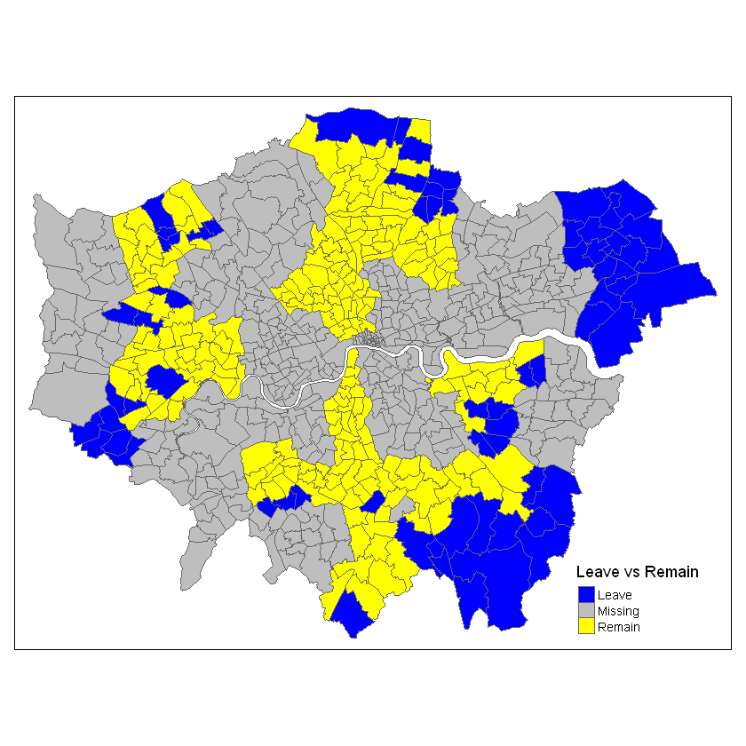

```r
tm_shape(LondonTrueWardsNewSF2) +
              tm_polygons("Remain_Leave_Missing",
                          style="jenks",
                          palette= c("blue", "grey", "yellow"),
                          legend.outside = TRUE,
                          legend.outside.position = c("bottom", "top"),
                          #auto.palette.mapping=FALSE,
                          title="Leave vs Remain",
                          )
```

### Note:

- Yellow and Blue is the standard Colour Scheme adopted in Media coverage. Discuss.

### Colour Brewer Scales

The idea behind choosing a good colormap is to find a good representation in 3D colorspace for your data set. The best colormap for any given data set depends on many things including:

- Whether representing form or metric data ([Ware])
- Your knowledge of the data set (e.g., is there a critical value from which the other values deviate?)
- If there is an intuitive color scheme for the parameter you are plotting
- If there is a standard in the field the audience may be expecting

https://matplotlib.org/3.1.1/tutorials/colors/colormaps.html  
hhttps://web.archive.org/web/20130510171310/http://www.albany.edu/faculty/fboscoe/papers/harrower2003.pdf

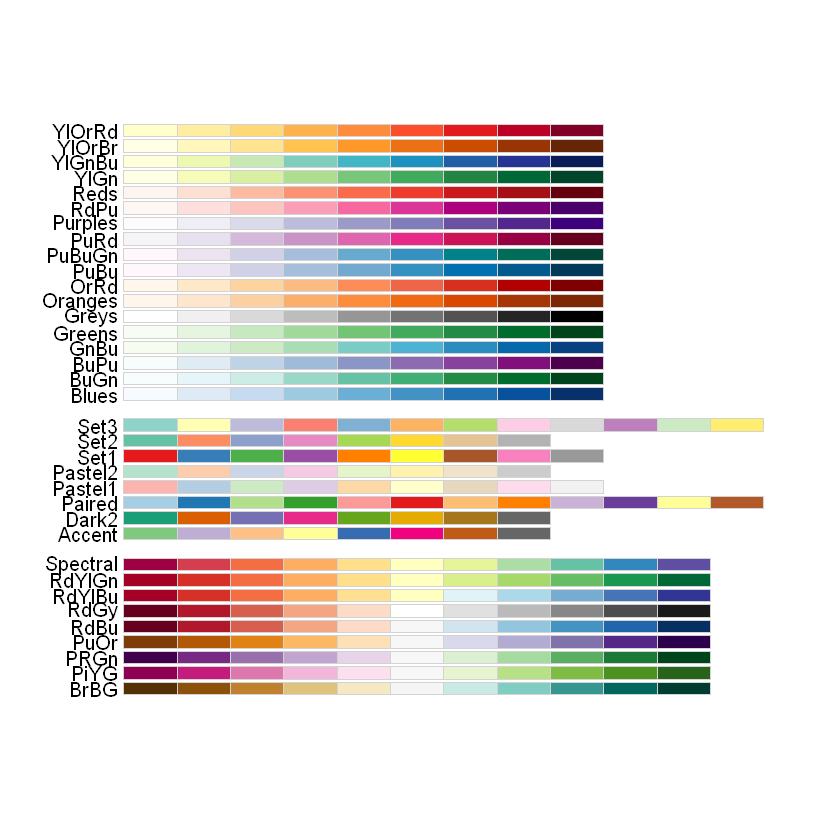

```r
display.brewer.all()
```

```
tmap mode set to plotting
```

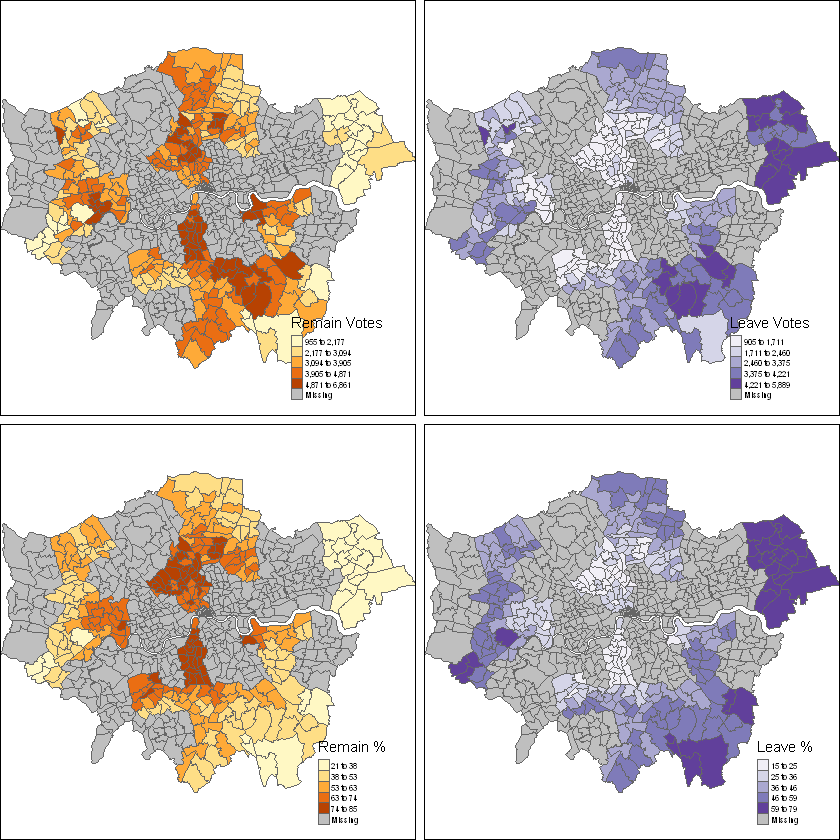

```r
tmap_mode("plot")
tm_shape(LondonTrueWardsNewSF2) +
    tm_polygons(c("Remain", "Leave","RemainR.", "LeaveR."), title=c("Remain Votes", "Leave Votes","Remain %", "Leave %"),
                style=c("jenks", "pretty"),
        palette=list(seq = "YlOrBr" , seq = "Purples",seq = "YlOrBr" , seq = "Purples"),
                   ) +
    tm_facets(sync = FALSE, ncol = 2) +
    tm_legend(
          legend.position = c("right", "bottom"),
          legend.title.size = 1.3,
          legend.text.size = 0.6)  +
  tm_layout(asp=1, outer.margins=c(0, 0, 0, 0),
      inner.margins=0)
```

### Observation

- Larger Counts in both Remian and Leave campls highlight more populated wards/greater voter turn out
- Remain Vote is stronger in more central inner city ward locations. Leave vote is stronger in outer boroughs and strongest to the east.

# 2 - Creating a Basic Geodemographic Classification

Reference: https://rpubs.com/adam_dennett/443357

```r
LondonWards <- readOGR("C:\\Users\\Admin\\ml16\\NewLondonWard\\NewLondonWard.shp")
LondonWardsSF <- st_as_sf(LondonWards)
LondonWardsDF <- st_set_geometry(LondonWardsSF,NULL)

attach(LondonWardsSF)
attach(LondonWardsDF)

#list features
#cbind(lapply(LondonWardsDF, class))

#clustering
#Create a new data frame just containing the two variables we are
#interested in
mydata<-as.data.frame(LondonWardsDF[,c("PctAged65p","PctWithNoQ")])
attach(mydata)
```

### Variable Check for Clustering:

Ensure variables are:

- Ranged on the same scale
- Normally distributed
- Not highly correlated

### Histogram

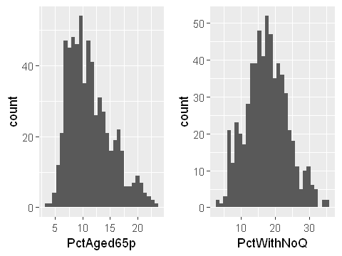

```r
backup_options <- options()
library(repr)
# Change plot size to 4 x 3
options(repr.plot.width=4, repr.plot.height=3)

library(grid)
grid.newpage()
#pushViewport(viewport(width=1.8, height=0.9, layout=grid.layout(1,2)))
pushViewport(viewport(layout=grid.layout(1,2)))

histplot <- ggplot(data=mydata, aes(x=PctAged65p))
plot1 = histplot +geom_histogram()
print(plot1, vp=viewport(layout.pos.col = 1))
histplot <- ggplot(data=mydata, aes(x=PctWithNoQ))
plot2 = histplot +geom_histogram()
print(plot2, vp=viewport(layout.pos.col = 2))
#– check variable distributions first
#histplot <- ggplot(data=mydata, aes(x=PctOwned11))
#histplot +geom_histogram()

#histplot <- ggplot(data=mydata, aes(x= PctNoQl11))
#histplot +geom_histogram()

#histplot <- ggplot(data=mydata, aes(x=Pct65plus))
#histplot +geom_histogram()
#histplot <- ggplot(data=mydata, aes(x=PctBame11))
#hist
#Rest Options for Plot Size
options(backup_options)
```

### Correlation

```r
df <- mydata[-c(3)]
head(df,3)
```

|  | PctAged65p | PctWithNoQ |
| --- | --- | --- |
| 0 | 14.033898 | 6.7 |
| 1 | 6.331639 | 20.5 |
| 2 | 11.040724 | 26.4 |

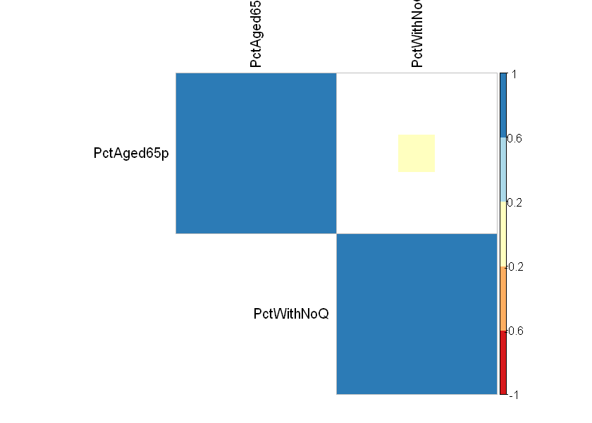

```r
#backup_options <- options()
# Change plot size to 4 x 3
options(repr.plot.width=7, repr.plot.height=5)

library(corrplot)
corrmatrix <- cor(mydata)
#corrplot(corrmatrix, method = 'number')
corrplot(corrmatrix, method = "square", type = "upper", tl.col = "black", order = "hclust", col = brewer.pal(n = 5, name = "RdYlBu"))
options(backup_options)
```

- Coefficient = 0.2
- Data meets non-correlated assumption.

### Cluster Selection

Some Options:

- Silhouette
- Elbow
- Gap Static

### Silhouette Score

https://medium.com/codesmart/r-series-k-means-clustering-silhouette-794774b46586

```r
library(cluster)
library(factoextra)
```

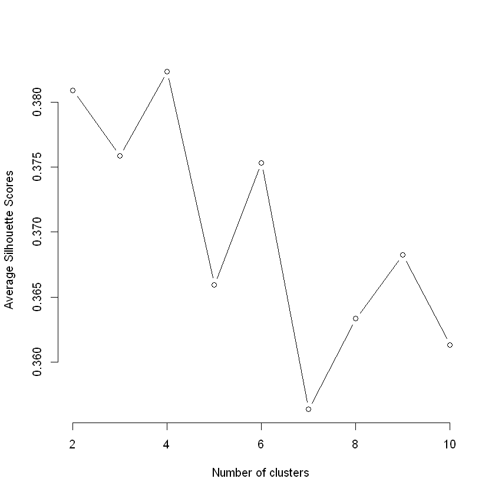

```r
silhouette_score <- function(k){
  km <- kmeans(df, centers = k, nstart=25)
  ss <- silhouette(km$cluster, dist(df))
  mean(ss[, 3])
}
k <- 2:10
avg_sil <- sapply(k, silhouette_score)
plot(k, type='b', avg_sil, xlab='Number of clusters', ylab='Average Silhouette Scores', frame=FALSE)
```

- Our silhouette scores suggests the optimal cluster arrangement = 4

### Note on K Means

In cluster analysis, the k-means algorithm can be used to partition the input data set into k partitions (clusters). However, the pure k-means algorithm is not very flexible, and as such is of limited use (except for when vector quantization as above is actually the desired use case). In particular, the parameter k is known to be hard to choose (as discussed above) when not given by external constraints. Another limitation is that it cannot be used with arbitrary distance functions or on non-numerical data. For these use cases, many other algorithms are superior.

### Cluster Plot

```r
# run a k-means to find 4 clusters – use 25 iterations
fit <- kmeans(mydata, 4, nstart=25) # 3 cluster solution
# get cluster means
centroid<-aggregate(mydata,by=list(fit$cluster),FUN=mean)
#print the results of the cluster groupings
centroid
```

| Group.1 | PctAged65p | PctWithNoQ |
| --- | --- | --- |
| 1 | 8.841289 | 18.58465 |
| 2 | 11.923679 | 26.52957 |
| 3 | 10.414632 | 10.37378 |
| 4 | 16.929174 | 17.15339 |

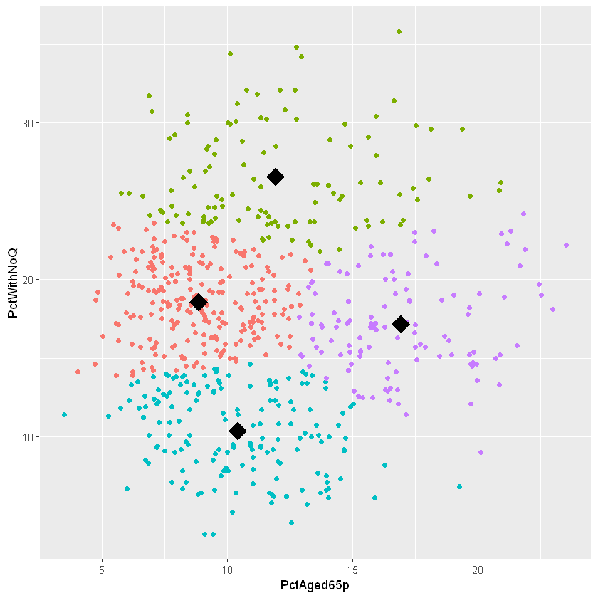

```r
# as we only have variables of two dimensions we can plot the clusters on a graph
p <- ggplot(mydata,aes(PctAged65p, PctWithNoQ))
p+geom_point(aes(colour=factor(fit$cluster)))+geom_point(data=centroid[,2:3],aes(PctAged65p, PctWithNoQ), size=7, shape=18)+ theme(legend.position="none")
```

#### Observation

- Low Percentage of Aged 65+
- Cluster 4 arguably represents more defined concentration of Variable mix

### Map of the GeoDemographic Classification

```r
head(mydata)
```

|  | PctAged65p | PctWithNoQ | cluster |
| --- | --- | --- | --- |
| 0 | 14.033898 | 6.7 | 3 |
| 1 | 6.331639 | 20.5 | 1 |
| 2 | 11.040724 | 26.4 | 2 |
| 3 | 12.017882 | 23.4 | 2 |
| 4 | 10.913086 | 17.3 | 1 |
| 5 | 10.536570 | 16.1 | 1 |

### ggplot

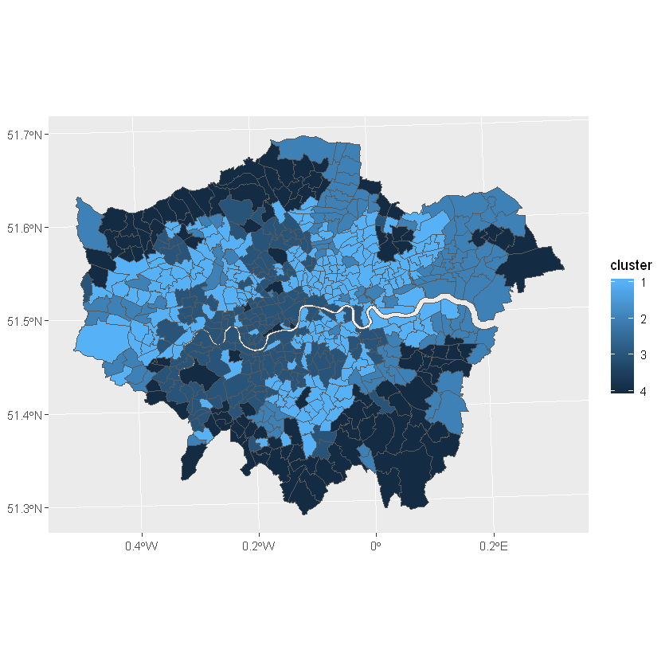

```r
library(repr)

mydata$cluster <- fit$cluster

#add the cluster groups to the LondonWards data frame
LondonWardsSF$cluster<-mydata$cluster
#merge the cluster results into a fortified dataframe for plotting (we made LondonGeom earlier)
#London_geom<-merge(London_geom,LondonWardsDF,by.x="id", by.y="Wardcode1")
#now map our geodeomographic classification
map <- ggplot(LondonWardsSF) + geom_sf(mapping = aes(fill=cluster))+scale_fill_continuous(breaks=c(1,2,3,4), trans='reverse')
map
```

### tmap

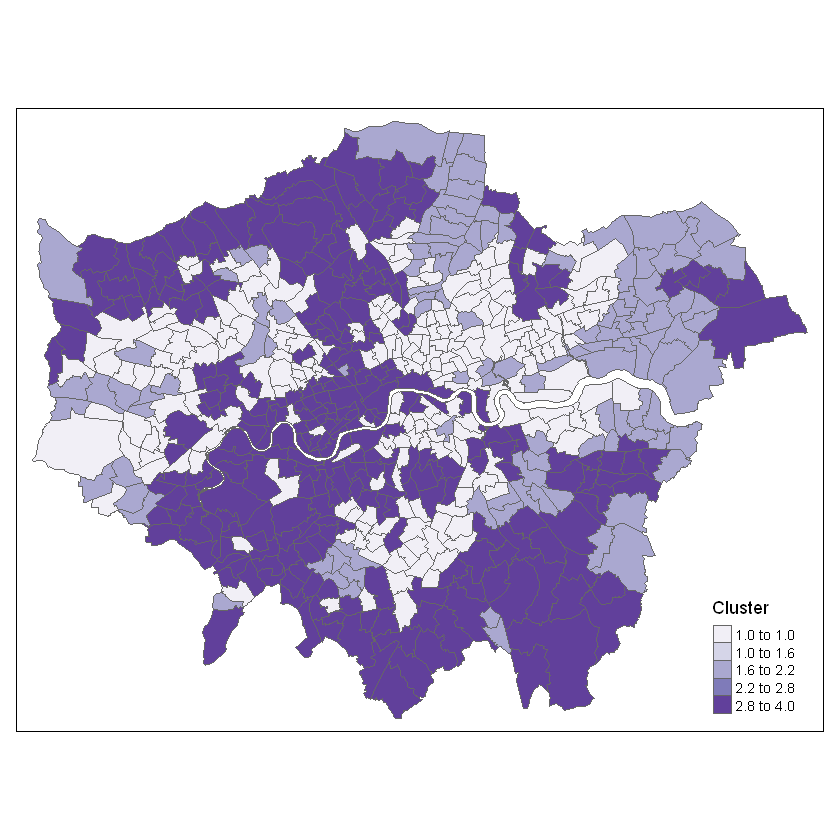

```r
tm_shape(LondonWardsSF) +
              tm_polygons("cluster",
                          style="jenks",
                          palette="Purples",
                          legend.outside = TRUE,
                          legend.outside.position = c("bottom", "top"),
                          auto.palette.mapping=FALSE,
                          title="Cluster")
```

### Note

- The distribution of Cluster Strength appears to mirror thhat of the Leave Vote in some areas. Lets create Facet maps to make it easier to compare the two distribution profiles.
- To Do: 3D Clustering with BAME Variable identified in Section 1

# 3 - Comparing Clusters with Election Result

### Ref Results vs Geo Demo Class Facet Maps with R Grid Package

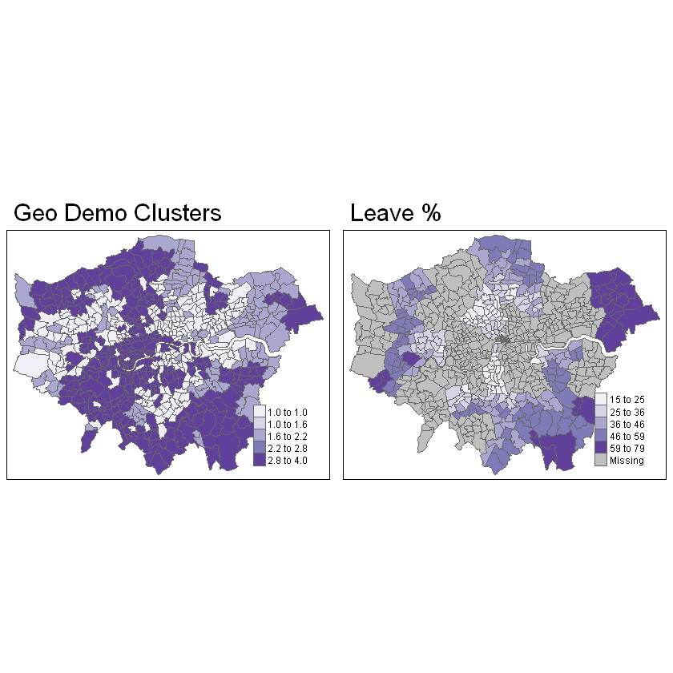

```r
#library(grid)
grid.newpage()
pushViewport(viewport(layout=grid.layout(1,2)))

plot1 = tm_shape(LondonWardsSF) +
              tm_polygons("cluster",
                          style="jenks",
                          palette="Purples",
                          legend.outside = TRUE,
                          legend.outside.position = c("bottom", "top"),
                          #auto.palette.mapping=FALSE,
                          title="") +
    tm_legend(main.title="Geo Demo Clusters",
          legend.position = c("right", "bottom"),
          legend.title.size = 0.8,
          legend.text.size = 0.6)

plot2 = tm_shape(LondonTrueWardsNewSF2) +
              tm_polygons("LeaveR.",
                          style="jenks",
                          palette="Purples",
                          legend.outside = TRUE,
                          legend.outside.position = c("bottom", "top"),
                          #auto.palette.mapping=FALSE,
                          title="") +
    tm_legend(main.title="Leave %",
          legend.position = c("right", "bottom"),
          legend.title.size = 0.8,
          legend.text.size = 0.6)

print(plot1, vp=viewport(layout.pos.col = 1))
print(plot2, vp=viewport(layout.pos.col = 2))
```

### Observation

- Geo Demographic Class Clusters strongest in outer boroughs where higher % of Leave Vote is also seen
- Exceptions to this pattern to be found in some central and north western wards
- Does Missing Ward Data complicate this assumption?

#### Note:

- Remove White Space from Plot
- How to Move Legend.Position (Right, Bottom) further out. Tip: Check TM_Layout and Aspect Ratio

# 4 - Regional Context

## 4.1 - UK Ward Maps

```r
### Open Filter
UKWMap <- newSP

###  SP to SF Conversion
newSF2 <- st_as_sf(UKWMap)

nrow(newSF2)
head(newSF2)
head(UKWMap)

### Get UK Election Data

#Nulls Removed
UKData2 <-read_csv("C:\\Users\\Admin\\ml16\\uk-ward-results-edit2.csv")
WardData4 <- data.frame(UKData2)

### Join Data
UKWardsNewSF2 <- merge(newSF2, WardData4, by.x = "wd16cd", by.y = "WardCode", all=TRUE)

### Check Missing Data
nrow(UKWardsNewSF2)
sum(is.na(UKWardsNewSF2$Leave))

class(UKWardsNewSF2)
head(UKWardsNewSF2)
```

```r
Plot1 <- qtm(UKWardsNewSF2, fill = "Remain.", title="%", title.position=c("right", "top"), fill.pallette = "Spectral" ) +
tm_legend(legend.position = c("right", "top"),
          main.title = "",
          main.title.position = "right")

Plot2 <- qtm(UKWardsNewSF2, fill = "Leave.", title="%", title.position=c("right", "top"), title.size="", fill.pallette = "Purples" ) +
tm_legend(legend.position = c("right", "top"),
          main.title = "",
          main.title.position = "right")
```

```r
tmap_mode("plot")
```

```
tmap mode set to plotting
```

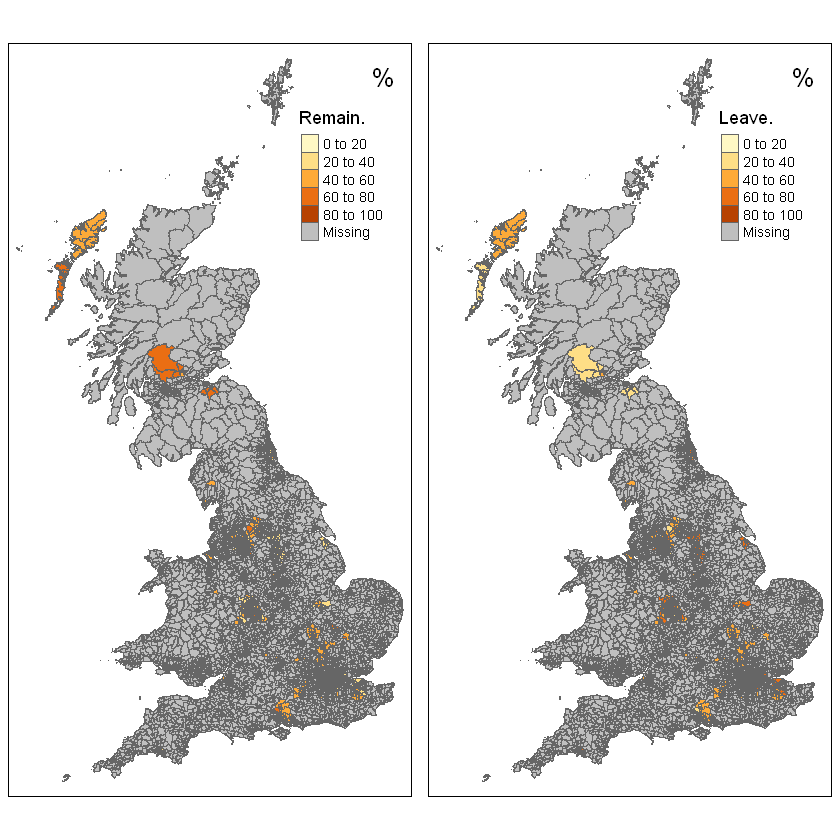

```r
#library(grid)
grid.newpage()
pushViewport(viewport(layout=grid.layout(1,2)))

print(Plot1, vp=viewport(layout.pos.col = 1))
print(Plot2, vp=viewport(layout.pos.col = 2))
```

### Note:

- Highlights the Missing Data from BBC Analysis.
- Comment on Freedom of Info and output of responses vs declines(or able vs not able).
- Hard to visually assimilate ward based data on UK scale.
- The 1000 Wards that were collected by the Data Journalist Analysis via LA FOI request, look under represented here.
- Lets translate and ward results into borough scaled data for facet comparison.
- An interactive map (tmap=plot) would be usefull to check our wards have joined correcty, and/or to better assimilate the data. Tmap = Plot is bug prone in IRKenal, possibly due to the large pagesize required for html/js maps.
- To Do: Fix ViewPort Colour Pallette Bug.

## 4.2 - UK Ward vs Borough Maps

```r
BoroughMapSF <- read_shape("C:\\Users\\Admin\\ml16\\England_lad_2011\\england_lad_2011.shp", as.sf = TRUE)

head(BoroughMapSF)

class(BoroughMapSF)

UKData3 <-read_csv("C:\\Users\\Admin\\ml16\\uk-ward-results-edit2.csv")
UKBorough3 <- data.frame(UKData3)


### Join on Borough Code

UKBoroughsNewSF <- merge(BoroughMapSF, UKBorough3, by.x = "name", by.y = "CountingArea", all=TRUE)

head(UKBoroughsNewSF)

sum(is.na(UKBoroughsNewSF$Leave))

nrow(UKBoroughsNewSF)
```

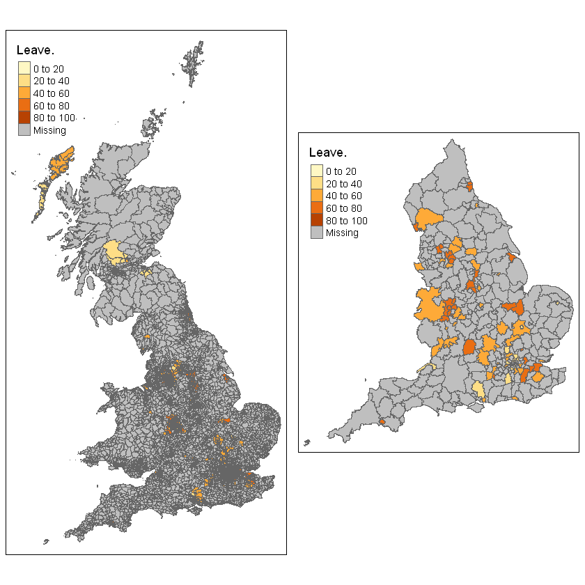

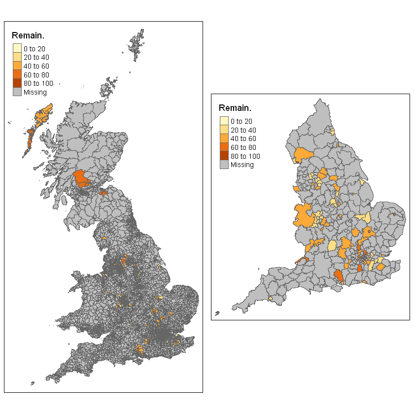

```r
#Leave:
Plot1 <- qtm(UKWardsNewSF2, fill = "Leave.", fill.pallette = "Purples" ) +
tm_legend(legend.position = c("left", "top"),
          main.title = "",
          main.title.position = "right")

Plot2 <- qtm(UKBoroughsNewSF, fill = "Leave.", fill.pallette = "Purples" ) +
tm_legend(legend.position = c("left", "top"),
          main.title = "",
          main.title.position = "right")

grid.newpage()
pushViewport(viewport(layout=grid.layout(1,2)))

print(Plot1, vp=viewport(layout.pos.col = 1))
print(Plot2, vp=viewport(layout.pos.col = 2))

#Remain

Plot1 <- qtm(UKWardsNewSF2, fill = "Remain.", fill.pallette = "Spectral" ) +
tm_legend(legend.position = c("left", "top"),
          main.title = "",
          main.title.position = "right")

Plot2 <- qtm(UKBoroughsNewSF, fill = "Remain.", fill.pallette = "Spectral" ) +
tm_legend(legend.position = c("left", "top"),
          main.title = "",
          main.title.position = "right")

#library(grid)
grid.newpage()
pushViewport(viewport(layout=grid.layout(1,2)))


print(Plot1, vp=viewport(layout.pos.col = 1))
print(Plot2, vp=viewport(layout.pos.col = 2))
```

### Note

- Does Borough Scale skew or confound any interesting Ward Votal distributions?

## 4.3 UK Borough Leave vs Remain Maps

```
tmap mode set to plotting
Warning message:
"The shape UKBoroughsNewSF contains empty units."Warning message:
"The shape UKBoroughsNewSF contains empty units."Warning message:
"The shape UKBoroughsNewSF contains empty units."Warning message:
"The shape UKBoroughsNewSF contains empty units."
```

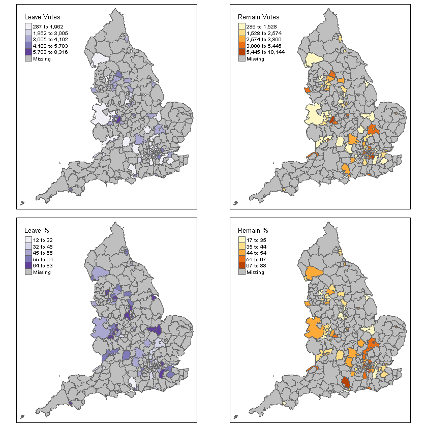

```r
tmap_mode("plot")

plot1 = tm_shape(UKBoroughsNewSF) +
              tm_polygons("Leave",
                          style="jenks",
                          palette="Purples",
                          #auto.palette.mapping=FALSE,
                          title="Leave Votes") +
    tm_legend(
          legend.position = c("left", "top"),
          legend.title.size = 0.8,
          legend.text.size = 0.5)

plot2 = tm_shape(UKBoroughsNewSF) +
              tm_polygons("Remain",
                          style="jenks",
                          palette="YlOrBr",
                          #auto.palette.mapping=FALSE,
                          title="Remain Votes") +
    tm_legend(
          legend.position = c("left", "top"),
          legend.title.size = 0.8,
          legend.text.size = 0.5)

plot3 = tm_shape(UKBoroughsNewSF) +
              tm_polygons("LeaveR.",
                          style="jenks",
                          palette="Purples",
                          #auto.palette.mapping=FALSE,
                          title="Leave %") +
    tm_legend(
          legend.position = c("left", "top"),
          legend.title.size = 0.8,
          legend.text.size = 0.5)

plot4 = tm_shape(UKBoroughsNewSF) +
              tm_polygons("RemainR.",
                          style="jenks",
                          palette="YlOrBr",
                          #auto.palette.mapping=FALSE,
                          title="Remain %") +
    tm_legend(
          legend.position = c("left", "top"),
          legend.title.size = 0.8,
          legend.text.size = 0.5)



#library(grid)
grid.newpage()
pushViewport(viewport(layout=grid.layout(2,2)))
print(plot1, vp=viewport(layout.pos.col = 1, layout.pos.row = 1))
print(plot2, vp=viewport(layout.pos.col = 2, layout.pos.row = 1))
print(plot3, vp=viewport(layout.pos.col = 1, layout.pos.row = 2))
print(plot4, vp=viewport(layout.pos.col = 2, layout.pos.row = 2))
### Display Interactive London Borough Map
```

### Note

- Is Leave Vote stronger further away from other UK Cities?
- BBC Analysis had 1/9 Responses from FOI Data Collection exercise
- Highlight Voter TurnOut/Electorate Size with Vote Count Facets

# 5 - Political Context and Background

#### Data Setup

```r
UKData_Contxt <-read_csv("C:\\Users\\Admin\\ml11\\DSS_Coursework_ASutton\\final_data.csv")
LondonData5 <- data.frame(UKData_Contxt)

LondonTrueWardsNewSF3 <- merge(LondonWMap, LondonData5, by.x = "wd16cd", by.y = "WardCode", all=TRUE)
head(LondonTrueWardsNewSF3)
```

### tmap

```
tmap mode set to plotting
```

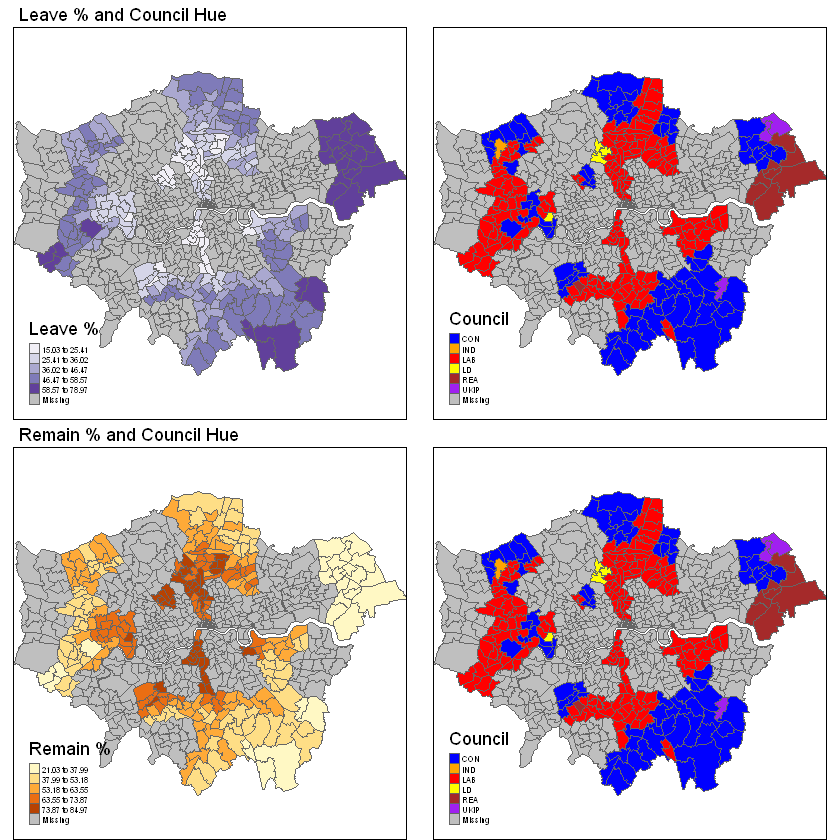

```r
tmap_mode("plot")
plot1 = tm_shape(LondonTrueWardsNewSF3) +
    tm_polygons("Leave_Percent",
                style="jenks",
                title="Leave %",
        palette="Purples",
                   ) +
    tm_legend(main.title = "Leave % and Council Hue",
          main.title.size = 0.9,
          legend.position = c("left", "bottom"),
          legend.title.size = 1.1,
          legend.text.size = 0.4)  +
  tm_layout(asp=1, outer.margins=c(0, 0, 0, 0),
      inner.margins=0)

plot2 = tm_shape(LondonTrueWardsNewSF3) +
    tm_polygons("Council_Party",
                style="pretty",
                title="Council",
        palette= c("blue", "orange", "red", "yellow", "brown", "purple", "grey"),
                   )  +
    tm_legend(main.title = " ",
          main.title.size = 0.9,
          legend.position = c("left", "bottom"),
          legend.title.size = 1.1,
          legend.text.size = 0.4)  +
  tm_layout(asp=1, outer.margins=c(0, 0, 0, 0),
      inner.margins=0)

plot3 = tm_shape(LondonTrueWardsNewSF3) +
    tm_polygons("Remain_Percent",
                style="jenks",
                title="Remain %",
        palette="YlOrBr",
                   ) +
    tm_legend(main.title = "Remain % and Council Hue",
          main.title.size = 0.9,
          legend.position = c("left", "bottom"),
          legend.title.size = 1.1,
          legend.text.size = 0.4)  +
  tm_layout(asp=1, outer.margins=c(0, 0, 0, 0),
      inner.margins=0)

plot4 = tm_shape(LondonTrueWardsNewSF3) +
    tm_polygons("Council_Party",
                style="pretty",
                title="Council",
        palette=c("blue", "orange", "red", "yellow", "brown", "purple", "grey"),
                   ) +
    tm_legend(main.title = " ",
          main.title.size = 0.9,
          legend.position = c("left", "bottom"),
          legend.title.size = 1.1,
          legend.text.size = 0.4)  +
  tm_layout(asp=1, outer.margins=c(0, 0, 0, 0),
      inner.margins=0)

grid.newpage()
pushViewport(viewport(layout=grid.layout(2,2)))
print(plot1, vp=viewport(layout.pos.col = 1, layout.pos.row = 1))
print(plot2, vp=viewport(layout.pos.col = 2, layout.pos.row = 1))
print(plot3, vp=viewport(layout.pos.col = 1, layout.pos.row = 2))
print(plot4, vp=viewport(layout.pos.col = 2, layout.pos.row = 2))
```

```
tmap mode set to plotting
Some legend labels were too wide. These labels have been resized to 0.47. Increase legend.width (argument of tm_layout) to make the legend wider and therefore the labels larger.
```

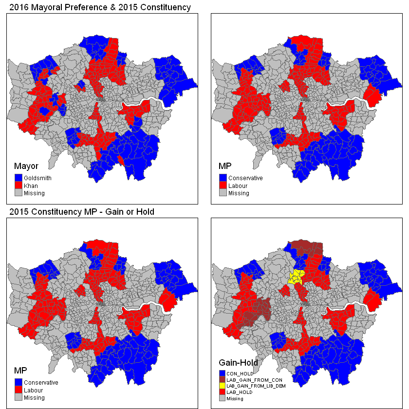

```r
tmap_mode("plot")
plot5 = tm_shape(LondonTrueWardsNewSF3) +
    tm_polygons( "London_Mayor_",
                style="jenks",,
                        title="Mayor",
        palette=c("blue", "red", "grey"),
                   ) +
    tm_legend(main.title = "2016 Mayoral Preference & 2015 Constituency",
          main.title.size = 0.9,
          legend.position = c("left", "bottom"),
          legend.title.size = 1.1,
          legend.text.size = 0.6)  +
  tm_layout(asp=1, outer.margins=c(0, 0, 0, 0),
      inner.margins=0)

plot6 = tm_shape(LondonTrueWardsNewSF3) +
    tm_polygons("Constituency_Party",
                style="pretty",
                        title="MP",
        palette=c("blue", "red", "grey"),
                   ) +
    tm_legend(main.title = " ",
          main.title.size = 0.9,
          legend.position = c("left", "bottom"),
          legend.title.size = 1.1,
          legend.text.size = 0.6)  +
  tm_layout(asp=1, outer.margins=c(0, 0, 0, 0),
      inner.margins=0)

plot7 = tm_shape(LondonTrueWardsNewSF3) +
    tm_polygons("Constituency_Party",
                popup.vars="WardName",
                style="jenks",
                title="MP",
                palette=c("blue", "red", "grey"),
               ) +
    tm_legend(main.title = "2015 Constituency MP - Gain or Hold",
          main.title.size = 0.9,
          legend.position = c("left", "bottom"),
          legend.title.size = 1.1,
          legend.text.size = 0.6)  +
  tm_layout(asp=1, outer.margins=c(0, 0, 0, 0),
      inner.margins=0)

plot8 = tm_shape(LondonTrueWardsNewSF3) +
    tm_polygons("Gain_Hold",
                popup.vars="WardName",
                style="pretty",
                title="Gain-Hold",
                palette=c("blue", "brown", "yellow", "red", "grey"),
               ) +
    tm_legend(main.title = " ",
          main.title.size = 0.9,
          legend.position = c("left", "bottom"),
          legend.title.size = 1.1,
          legend.text.size = 0.5)  +
  tm_layout(asp=1, outer.margins=c(0, 0, 0, 0),
      inner.margins=0)

grid.newpage()
pushViewport(viewport(layout=grid.layout(2,2)))
print(plot5, vp=viewport(layout.pos.col = 1, layout.pos.row = 1))
print(plot6, vp=viewport(layout.pos.col = 2, layout.pos.row = 1))
print(plot7, vp=viewport(layout.pos.col = 1, layout.pos.row = 2))
print(plot8, vp=viewport(layout.pos.col = 2, layout.pos.row = 2))
```

### Note:

- To Do: Trim White Space
- Highlight Political Affiliations or Votal Outcomes with Leave/Remain distribution
- Londons Leave Vote strongly associated with Conservate Vote
- Strongest Leave Wards(located to the north east) are not UKIP, CON or LAB but REA(Resi Assoc) Councils
- Mayoral Vote closely linked to Council Hue. Some inner Constituencies(eg Kensington, Camden) more split.

# Interactive Maps

```r
#tmap_mode("view")
tm_shape(LondonTrueWardsNewSF3) +
    tm_polygons(c( "Constituency_Party", "Gain_Hold"),
                popup.vars="WardName",
                style=c("jenks", "pretty"),
                palette=list(c("blue", "red", "grey"), c("blue", "brown", "yellow", "red", "grey") ),
               ) +
    tm_facets(sync = FALSE, ncol = 2) +
    tm_legend(
          legend.position = c("right", "bottom"),
          legend.title.size = 0.9,
          legend.text.size = 0.6)  +
  tm_layout(asp=1, outer.margins=c(0, 0, 0, 0),
      inner.margins=0)
```

- Issue with Embedded Interactive Maps in IRKernal
- https://cran.r-project.org/web/packages/tmap/vignettes/tmap-getstarted.html

# Extension:

## 6 - Swing Measurement and Ideological Polarisation in Party Systems

Brewer’s Politics (published by Cassell) Nicholas Comfort describes swing in the following terms:

“The statistical measure by which the switch of voters from one party to another on a national or constituency basis can be judged. It is calculated by adding the rise in one party’s vote to the fall of the other, and dividing by two.”

## 7 - Summary Visualisations

- Tableau Quick Plots
- Data Highlighting:
  - Postal Vote Variation
  - Ward Variation from Parent Borough

## 8 - MRP

The multilevel regression part of MRP lets us estimate reliable relationships between opinion and demographic and geographic characteristics of a survey sample, and post-stratification corrects for differences between the sample and the population.

Multilevel regression and post-stratification (MRP) (Little 1993; Lax and Phillips 2009; Park, Gelman, and Bafumi 2004) has been shown to be an effective method of adjusting the sample so that it is representative of the population for a set of key variables. Recent work has demonstrated the effectiveness of MRP when there are a number of suspected interactions between these variables (Ghitza and Gelman 2013), replicated by Lei, Gelman, and Ghitza (2017). While Ghitza and Gelman (2013) use approximate marginal maximum likelihood estimates; Lei, Gelman, and Ghitza (2017) implement a fully Bayesian approach through Stan.

#### Reference:

https://scholar.princeton.edu/sites/default/files/jkastellec/files/mrp_primer.pdf  
https://www.dataforprogress.org/blog/2018/6/19/data-demystified-an-introduction-to-mrp-and-demographic-sorting  
https://www.r-bloggers.com/gelmans-mrp-in-r-what-is-this-all-about/

1. Gather national opinion polls
2. Recode these polls as necessary so that they can be combined into a single internally-consistent dataset
3. You may also want to create a separate dataset of state-level predictors.
4. Collect census data to enable poststratification.
5. Fit a regression model for an individual survey response given demographics and geography.
6. Poststratify the demographic-geographic types.

#### 1 - R Survey Package Example

Reference: https://timmastny.rbind.io/blog/poststratification-with-dplyr/

```r
vote_yes <- c(rep(0, 25*(1-0.76)),
              rep(1, 25*0.76),
              rep(0, 50*(1-0.3)),
              rep(1, 50*0.3))
vote_yes
```

1. 0

2. 0

3. 0

4. 0

5. 0

6. 0

7. 1

8. 1

9. 1

10. 1

11. 1

12. 1

13. 1

14. 1

15. 1

16. 1

17. 1

18. 1

19. 1

20. 1

21. 1

22. 1

23. 1

24. 1

25. 1

26. 0

27. 0

28. 0

29. 0

30. 0

31. 0

32. 0

33. 0

34. 0

35. 0

36. 0

37. 0

38. 0

39. 0

40. 0

41. 0

42. 0

43. 0

44. 0

45. 0

46. 0

47. 0

48. 0

49. 0

50. 0

51. 0

52. 0

53. 0

54. 0

55. 0

56. 0

57. 0

58. 0

59. 0

60. 0

61. 1

62. 1

63. 1

64. 1

65. 1

66. 1

67. 1

68. 1

69. 1

70. 1

71. 1

72. 1

73. 1

74. 1

75. 1

```r
mean(vote_yes)
```

0.453333333333333

```r
library(tidyverse)
```

```r
poll_data <- tibble(
  group = c(rep("A", 25), rep("B", 10)),
  yes = c(rep(1, 19), rep(0, 6), rep(1, 3), rep(0, 7))
)
poll_data %>%
  group_by(group) %>%
  summarise(count = n())
```

| group | count |
| --- | --- |
| A | 25 |
| B | 10 |

```r
Census <- tibble(
  group = c("A", "B"),
  pop = c(25, 50)
)
Census
```

| group | pop |
| --- | --- |
| A | 25 |
| B | 50 |

```r
mean(poll_data$yes)
```

0.628571428571429

```r
group_support <- poll_data %>%
  group_by(group) %>%
  summarise(perc_support = mean(yes))
group_support
```

| group | perc_support |
| --- | --- |
| A | 0.76 |
| B | 0.30 |

```r
overall_support <- group_support %>%
  summarise(total_support = sum(perc_support * Census$pop/sum(Census$pop)))
overall_support
```

| total_support |
| --- |
| 0.4533333 |

```r
install.packages('survey')
```

```r
library(survey)
data(api)
```

```r
Census <- tibble(
  stype = c("E", "H", "M"),
  pop = c(4421, 755, 1018)
)
```

```r
d <- apistrat %>% as.tibble()
d %>%
  group_by(stype) %>%
  summarise(school_count = n())
```

| stype | school_count |
| --- | --- |
| E | 100 |
| H | 50 |
| M | 50 |

```r
d.group.ave <- d %>%
  group_by(stype) %>%
  summarise(ave_score = mean(api00))
d.group.ave
```

| stype | ave_score |
| --- | --- |
| E | 674.43 |
| H | 625.82 |
| M | 636.60 |

```r
d.total.ave <- d.group.ave %>%
  summarise(ave_score = sum(ave_score * Census$pop/sum(Census$pop)))
d.total.ave
```

| ave_score |
| --- |
| 662.2874 |

```r
apipop %>% as.tibble() %>%
  summarise(mean(api00))
```

| mean(api00) |
| --- |
| 664.7126 |

```r
d.group.enroll <- d %>%
  group_by(stype) %>%
  summarise(enroll = sum(enroll))
d.group.enroll
```

| stype | enroll |
| --- | --- |
| E | 41678 |
| H | 66035 |
| M | 41624 |

```r
group_sizes <- c(100, 50, 50)
d.tot.enroll <- d.group.enroll %>%
  summarise(total_enroll = sum(enroll * Census$pop/group_sizes))
d.tot.enroll
```

| total_enroll |
| --- |
| 3687178 |

```r
apipop %>% as.tibble() %>%
  summarise(total=sum(enroll, na.rm=TRUE))
```

| total |
| --- |
| 3811472 |

```r
d.api.tot <- d %>%
  group_by(stype) %>%
  summarise(tot_api = sum(api00))
d.api.tot
```

| stype | tot_api |
| --- | --- |
| E | 67443 |
| H | 31291 |
| M | 31830 |

```r
d.api.mean <- d.api.tot %>%
  summarise(api_mean = sum(tot_api * Census$pop/group_sizes)/6194)
d.api.mean
```

| api_mean |
| --- |
| 662.2874 |

#### 2 - MRP for London Census Data and EU Referendum Preference